# FEC Individual Contributions in Pennsylvania for 2016 Election by Jyothi Are

[output not shown]

I would like to answer the following questions with this analysis.

1.Do the Party line contributions show who would win the 2016 Election?

2.Which candidate in each party received the most contributions?

3.Is there any patterns that could be noted based on the employment status of the contributor?

4.Which candidate have the most supporters if not the most money contributed?

5.Does gender have an effect on the way contributions are made for each candidate?

6.Does location have an effect on the way contributions are made?

# Univariate Plots Section

```
## 'data.frame':    252093 obs. of  28 variables:
##  $ CMTE_ID             : chr  "C00545301" "C00333740" "C00333740" "C00333740" ...
##  $ AMNDT_IND           : chr  "N" "N" "N" "N" ...
##  $ RPT_TP              : chr  "Q1" "Q1" "Q1" "Q1" ...
##  $ TRANSACTION_PGI     : chr  "P" "P" "G" "P" ...
##  $ IMAGE_NUM           : num  1.6e+10 1.6e+10 1.6e+10 1.6e+10 1.6e+10 ...
##  $ TRANSACTION_TP      : chr  "15" "15" "15" "15" ...
##  $ ENTITY_TP           : chr  "IND" "IND" "IND" "IND" ...
##  $ NAME                : chr  "AUGUST, LINDA" "ANDERSON, JAMES MR." "ANDERSON, JAMES MR." "AVERY, WILLIAM J. MR." ...
##  $ CITY                : chr  "PHILADELPHIA" "NEW HOPE" "NEW HOPE" "GWYNEDD" ...
##  $ STATE               : chr  "PA" "PA" "PA" "PA" ...
##  $ ZIP_CODE            : int  19130 18938 18938 19437 19114 190206336 19020 19020 190120202 190120202 ...
##  $ EMPLOYER            : chr  "" "ANDERSON CONSTRUCTION" "ANDERSON CONSTRUCTION" "N/A" ...
##  $ OCCUPATION          : chr  "" "CEO" "CEO" "RETIRED" ...
##  $ TRANSACTION_DT      : int  3252015 3092015 3092015 3092015 3092015 3092015 3092015 3092015 3092015 3092015 ...
##  $ TRANSACTION_AMT     : int  1000 2600 2600 1000 500 2600 2300 300 400 2200 ...
##  $ OTHER_ID            : chr  "" "" "" "" ...
##  $ TRAN_ID             : chr  "SA11AI.4139" "SA11AI.10347" "SA11AI.10348" "SA11AI.10380" ...
##  $ FILE_NUM            : int  1002453 1002496 1002496 1002496 1002496 1002496 1002496 1002496 1002496 1002496 ...
##  $ MEMO_CD             : chr  "" "" "" "" ...
##  $ MEMO_TEXT           : chr  "" "" "" "" ...
##  $ SUB_ID              : num  4.04e+18 4.04e+18 4.04e+18 4.04e+18 4.04e+18 ...
##  $ CAND_ID             : chr  "H2PA13078" "H8PA01153" "H8PA01153" "H8PA01153" ...
##  $ CAND_NAME           : chr  "MARGOLIES-MEZVINSKY, MARJORIE" "BRADY, ROBERT A" "BRADY, ROBERT A" "BRADY, ROBERT A" ...
##  $ CAND_PTY_AFFILIATION: chr  "DEM" "DEM" "DEM" "DEM" ...
##  $ CMTE_NM             : chr  "MARJORIE 2014" "BOB BRADY FOR CONGRESS" "BOB BRADY FOR CONGRESS" "BOB BRADY FOR CONGRESS" ...
##  $ CMTE_PTY_AFFILIATION: chr  "DEM" "DEM" "DEM" "DEM" ...
##  $ CMTE_TP             : chr  "H" "H" "H" "H" ...
##  $ CAND_OFFICE         : chr  "H" "H" "H" "H" ...
```

```
## [1] 252093
```

```
## [1] 28
```

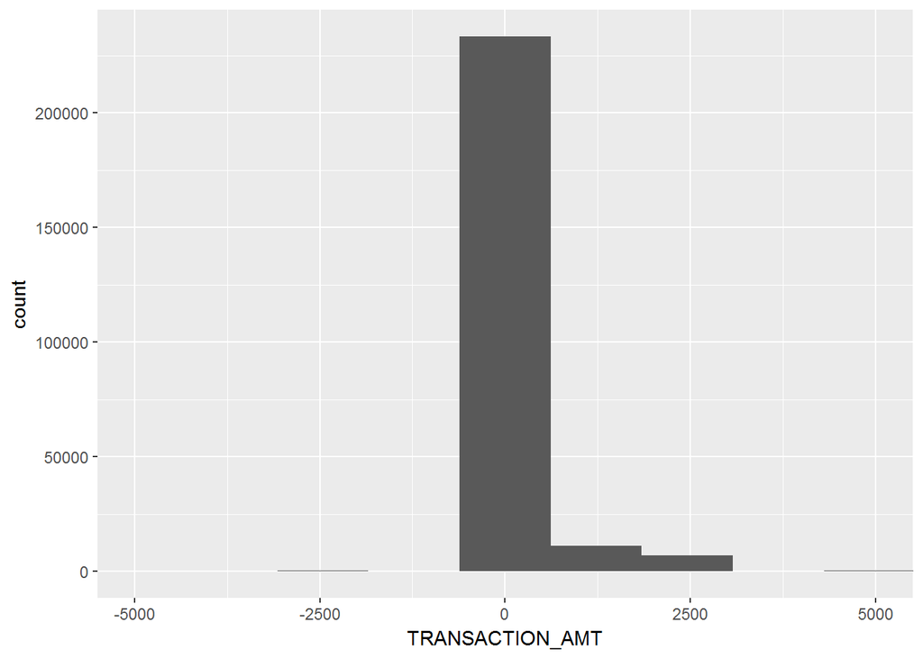

> The graphs show many outliers and also negative contribution amounts which must be returns when it exceeds the FEC individual amounts per election. As Per FEC $2700 is the limit for individual contributions.So I will remove all amounts above that and also the negative amounts.

```
## [1] 599
```

```
## [1] 691
```

Around 1290 of the contributions are removed.

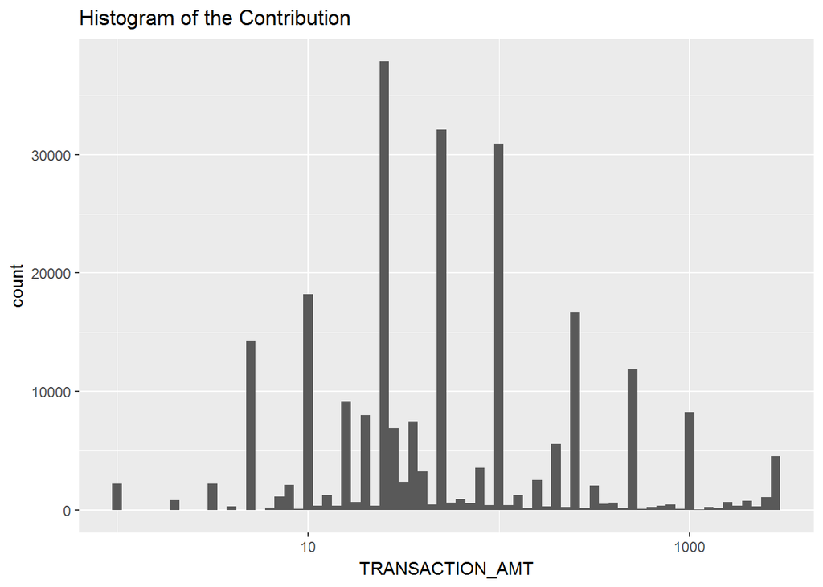

```
##
##   250    10   100    50    25
## 16514 18238 30556 31258 37529
```

```
##    Min. 1st Qu.  Median    Mean 3rd Qu.    Max.
##     1.0    25.0    50.0   198.4   100.0  2700.0
```

```
## [1] 250723
```

> This gives a better perspective to see how the contributions are distributed. The maximum number of contributions made are $25 . The distribution looks fairly normal . The median contribution is $50 and the mean is $198.4

### What is the structure of your dataset?

There are 252093 contributions and 28 variables. The variables that interest to me and I will be using are:

CMTE_ID - Committee ID  
NAME - Contributor Full Name  
ZIP_CODE - Contribute zip code  
EMPLOYER - Contribute employer  
OCCUPATION - Contributer occupation  
TRANSACTION_DT -Date of contribution  
TRANSACTION_AMT - Contribution amount  
CAND_ID - Candidate election commission given ID  
CAND_NAME - Candidate Name  
CAND_PTY_AFFILIATION - Candidate party affiliation  
CAND_OFFICE - Candidate office

### Other observations:

.Most people contribute small amount of money. .The median contribution amount is $50 and highest number of people made a contribution amount of $25. .The democratic party receive the most number of donations. .Retired people make the most number of contributions.

### What other features in the dataset do you think will help support your investigation into your feature(s) of interest?

Transforming to log10 to better understand the distribution of the contribution. The distribution looks normal and the data illustrated that most donors made small amount of contributions.

### Did you create any new variables from existing variables in the dataset?

I will need to add more variables such as candidate first name to find the gender of the candidate , donors’ gender and donors location (longitude and latitude) based on zip code.

### Of the features you investigated, were there any unusual distributions? Did you perform any operations on the data to tidy, adjust, or change the form of the data? If so, why did you do this?

The operations I had to perform to extract the data is mostly filtering and joining with some header tables to extract the data into a csv file to read .

The additional variables added to the data are:

first_name: contributor’s first name will be used to predict gender.  
gender: contributor’s gender.  
Latitude: contributor’s latitude for map creation.  
Longitude: contributor’s longitude for map creation.

After adding the variables, I wonder what the contribution distribution looks like across the parties, candidates, genders and occupations.

# Bivariate Plots Section

```
## # A tibble: 3 x 5
##   CAND_PTY sum_party number_of_candidate mean_party      n
##   <chr>        <int>               <int>      <dbl>  <int>
## 1 DEM       25716138                 243     105828 175239
## 2 OTHERS      142737                  13      10980    552
## 3 REP       22064600                 257      85854  67434
```

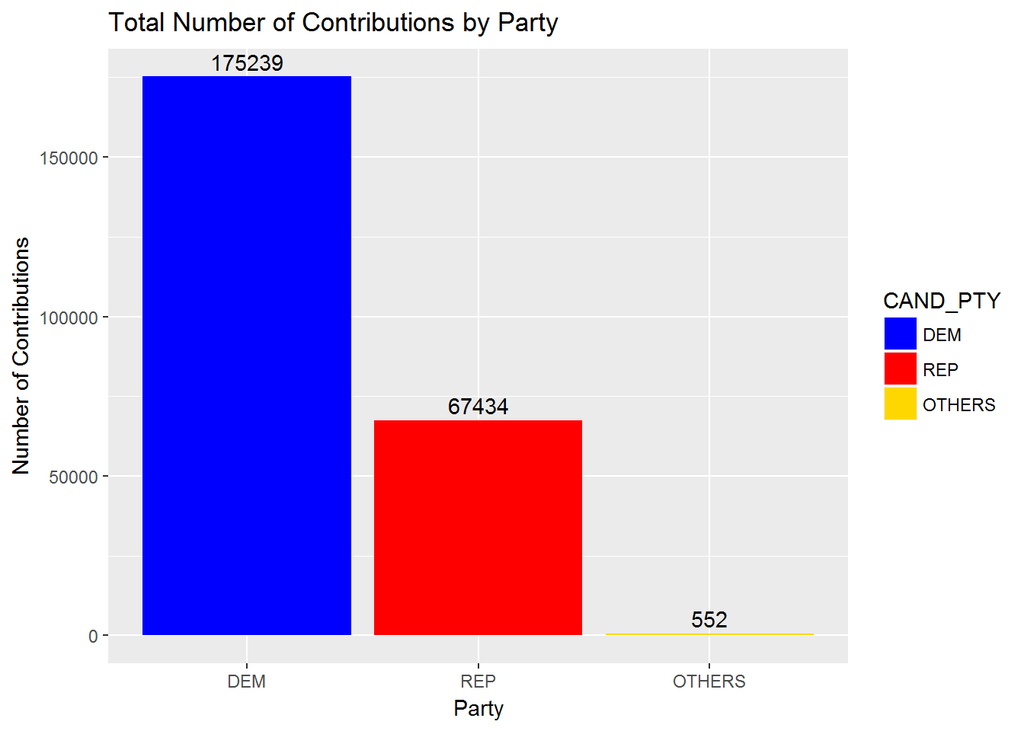

```
## [1] 243225
```

Total number of donations made to the presidential election were near 243K, and the Democratic party took more than 175K and almost 3 times of the number of donations made to the Republican party at 67 k. But the election results definitely do not reflect the donations. It is interesting to dig more deeper.

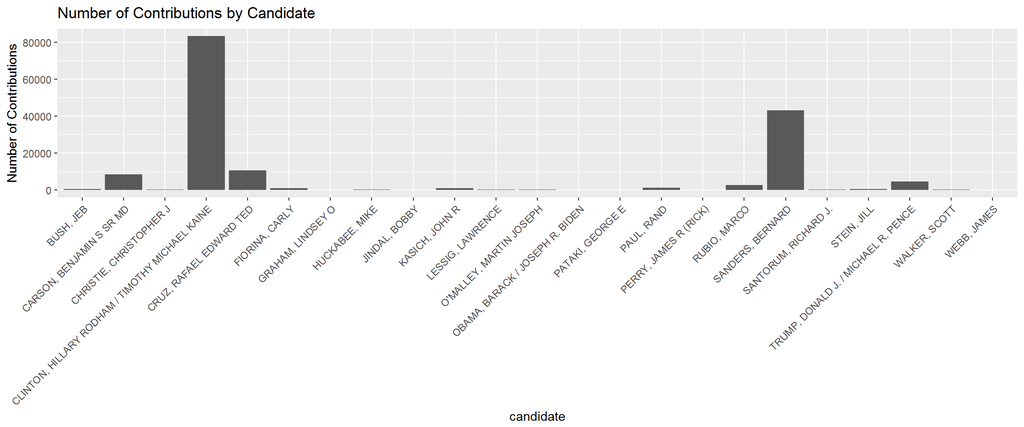

There were total 23 candidates, Hillary Clinton was the leader in the number of contributions, followed by Bernard Sanders, then Ted Cruz for the Republican Party. Let us see who donated more males or females

```
## # A tibble: 2 x 3
##   gender sum_gen n_gen
##   <chr>    <int> <int>
## 1 female 7302528 83772
## 2 male   9747955 73088
```

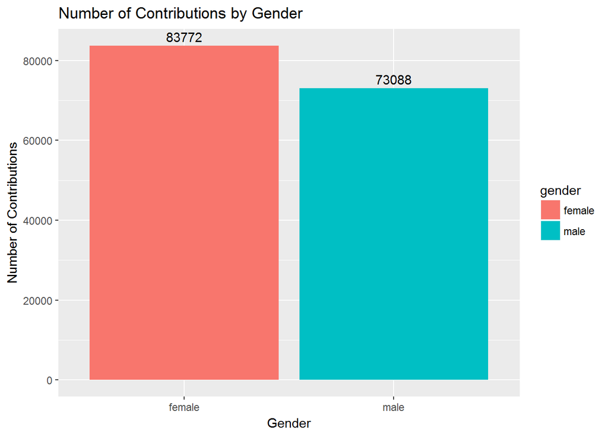

The female contributes are definitely more than the male contributers which is an interesting fact.I would have liked to see the range of age groups who contributed but we do not have that data.

Let us explore more if their profession effects how they donate and also between genders. I would also like to explore the contributions to Democrats and Republicans along the gender lines.

It would also be interesting to see the time line of these donations along the party lines.

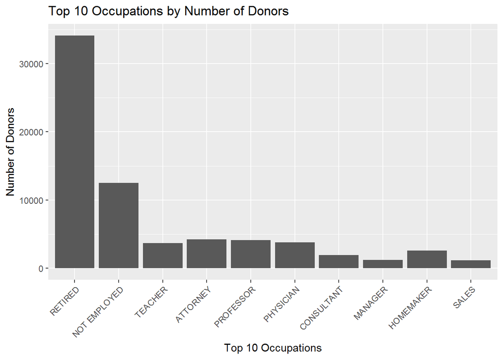

Retired people make the highest no of contributions followed by un employed. There were also several thousands of contributions where people choose not to divulge the profession. But with the data reported the retired are the highest contributors. When you look at the mean amount donated Attorney’s have the highest mean donated. We can safely assume attorneys do get paid more and also donate more for political parties to advocate their beliefs I guess.

```
##         Min.      1st Qu.       Median         Mean      3rd Qu.
## "2014-12-05" "2016-02-29" "2016-06-05" "2016-05-27" "2016-09-24"
##         Max.
## "2016-12-31"
```

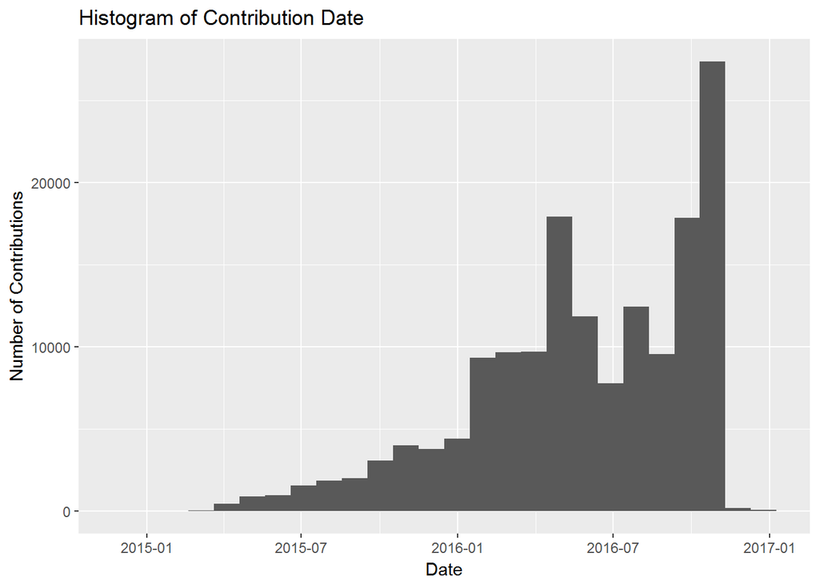

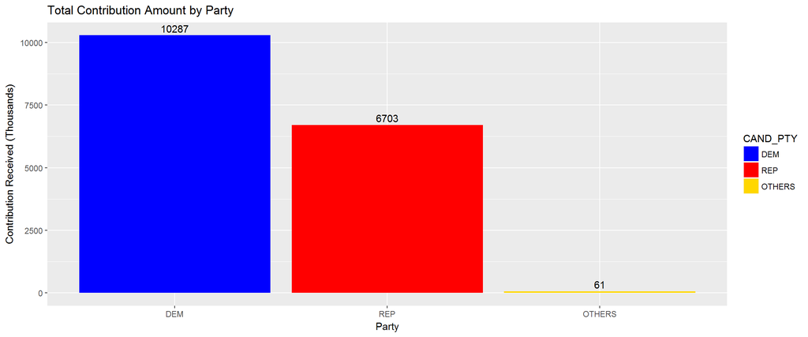

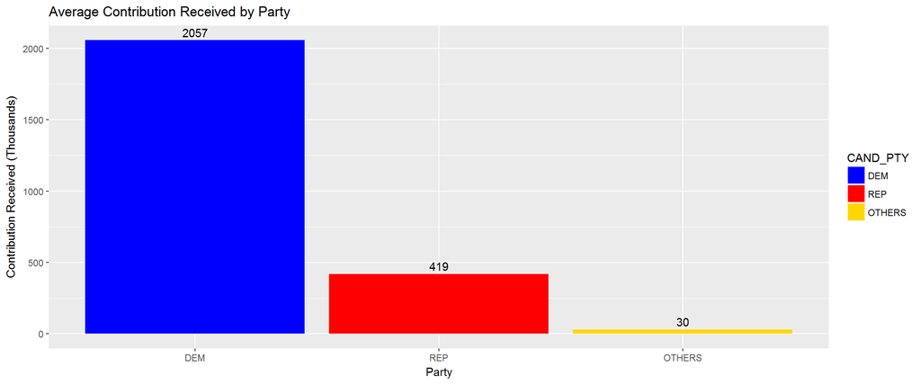

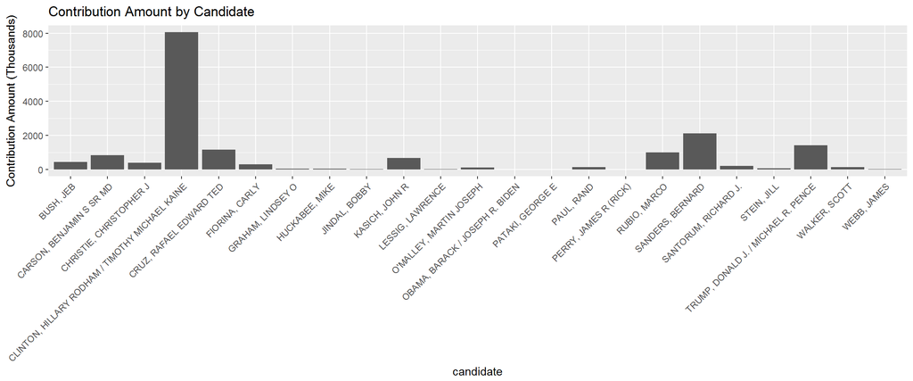

```
## [1] 17050483
```

The total contribution amount made to the presidential candidates grossed over 17 million US dollars in Pennsylvania. We can easily see where the money went.

Same with the number of contributions, Hillary Clinton received the most contribution amount followed by Bernard Sanders then Donald Trump.

The contributions makes sense as recently more often than not the state went democratic but despite the contributions it is very interesting to note that Republicans and TRUMP won the state despite the story the contributions tell. It definitely causes one to wonder about the relation between contributions and actual votes.

To see contribution patterns between parties and candidates, I start with box plots

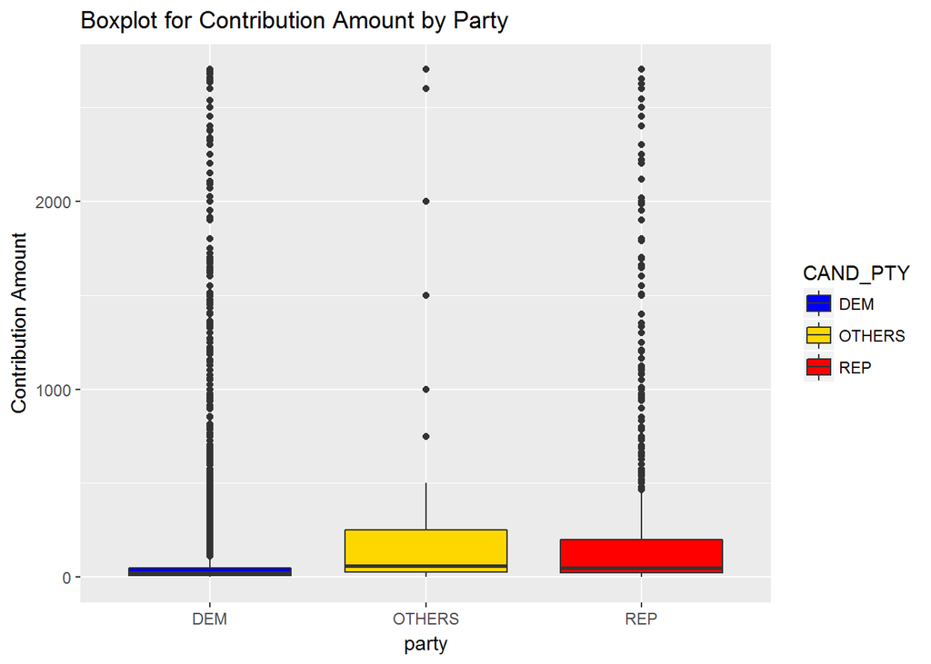

However, it is very hard to compare contributions among all parties at a glance because there are so many outliers. I will apply log scale and remove the ‘others’ party from now on because my analysis is focused on the Democratic party and the Republican party.

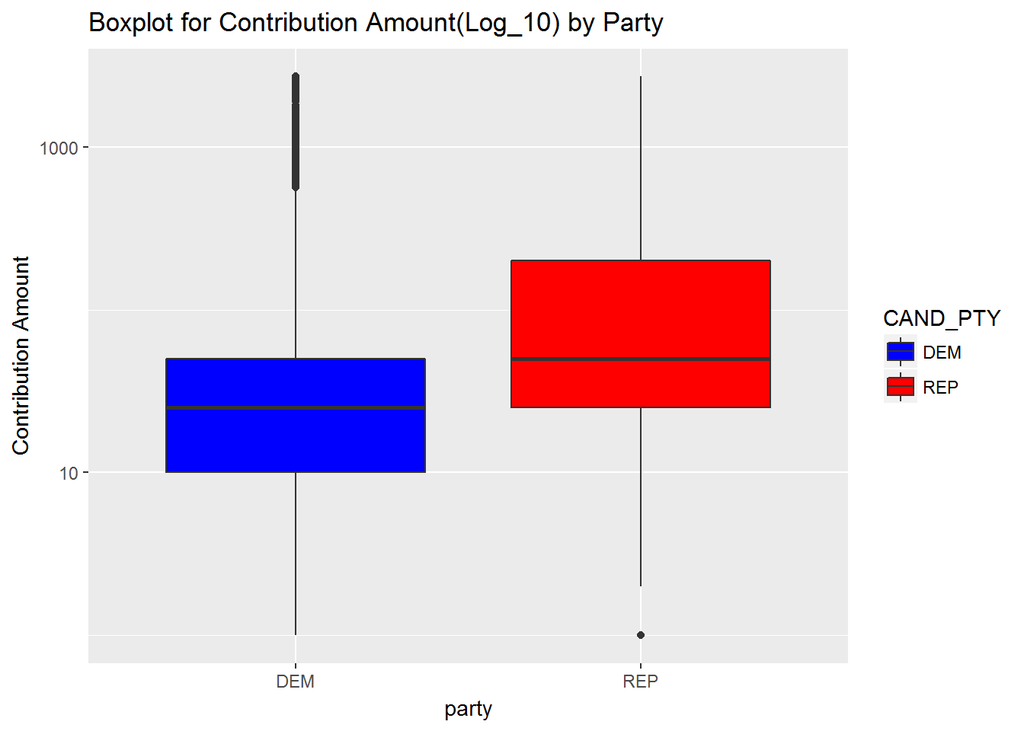

Although the Republican has the higher median and mean, the Democrat has more outliers on the higher end of the contribution amount where as Republicans have more outliers in the lower end. This probably is a likely indication of the election results.

```
## fec_pa_Pres$CAND_NAME: BUSH, JEB
##    Min. 1st Qu.  Median    Mean 3rd Qu.    Max.
##       1     250    1000    1316    2700    2700
## --------------------------------------------------------
## fec_pa_Pres$CAND_NAME: CARSON, BENJAMIN S SR MD
##    Min. 1st Qu.  Median    Mean 3rd Qu.    Max.
##    1.00   25.00   50.00   99.32  100.00 2700.00
## --------------------------------------------------------
## fec_pa_Pres$CAND_NAME: CHRISTIE, CHRISTOPHER J
##    Min. 1st Qu.  Median    Mean 3rd Qu.    Max.
##      25     500    1000    1410    2700    2700
## --------------------------------------------------------
## fec_pa_Pres$CAND_NAME: CLINTON, HILLARY RODHAM / TIMOTHY MICHAEL KAINE
##    Min. 1st Qu.  Median    Mean 3rd Qu.    Max.
##    1.00   10.00   25.00   96.76   50.00 2700.00
## --------------------------------------------------------
## fec_pa_Pres$CAND_NAME: CRUZ, RAFAEL EDWARD TED
##    Min. 1st Qu.  Median    Mean 3rd Qu.    Max.
##     1.0    25.0    50.0   109.8   100.0  2700.0
## --------------------------------------------------------
## fec_pa_Pres$CAND_NAME: FIORINA, CARLY
##    Min. 1st Qu.  Median    Mean 3rd Qu.    Max.
##     3.0    50.0   100.0   325.1   500.0  2700.0
## --------------------------------------------------------
## fec_pa_Pres$CAND_NAME: GRAHAM, LINDSEY O
##    Min. 1st Qu.  Median    Mean 3rd Qu.    Max.
##    25.0    50.0   175.0   731.5  1000.0  2700.0
## --------------------------------------------------------
## fec_pa_Pres$CAND_NAME: HUCKABEE, MIKE
##    Min. 1st Qu.  Median    Mean 3rd Qu.    Max.
##     1.0    25.0    50.0   206.2   100.0  2700.0
## --------------------------------------------------------
## fec_pa_Pres$CAND_NAME: JINDAL, BOBBY
##    Min. 1st Qu.  Median    Mean 3rd Qu.    Max.
##    20.0    50.0   100.0   584.2   500.0  2700.0
## --------------------------------------------------------
## fec_pa_Pres$CAND_NAME: KASICH, JOHN R
##    Min. 1st Qu.  Median    Mean 3rd Qu.    Max.
##    10.0   100.0   250.0   661.1  1000.0  2700.0
## --------------------------------------------------------
```

[output cut: 36 more lines]

```
## fec_pa_Pres$CAND_NAME: STEIN, JILL
##    Min. 1st Qu.  Median    Mean 3rd Qu.    Max.
##     1.0    29.0    50.0   173.8   250.0  2700.0
## --------------------------------------------------------
## fec_pa_Pres$CAND_NAME: TRUMP, DONALD J. / MICHAEL R. PENCE
##    Min. 1st Qu.  Median    Mean 3rd Qu.    Max.
##     3.0   100.0   250.0   320.3   250.0  2700.0
## --------------------------------------------------------
## fec_pa_Pres$CAND_NAME: WALKER, SCOTT
##    Min. 1st Qu.  Median    Mean 3rd Qu.    Max.
##    10.0   250.0   500.0   817.8  1000.0  2700.0
## --------------------------------------------------------
## fec_pa_Pres$CAND_NAME: WEBB, JAMES
##    Min. 1st Qu.  Median    Mean 3rd Qu.    Max.
##    50.0   100.0   250.0   445.5   375.0  2600.0
```

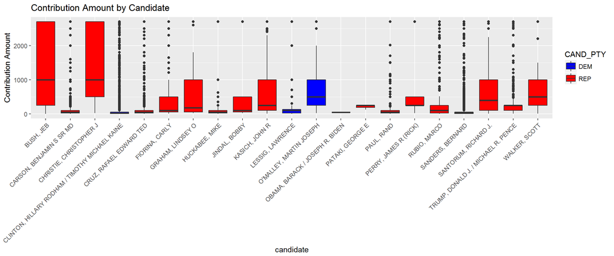

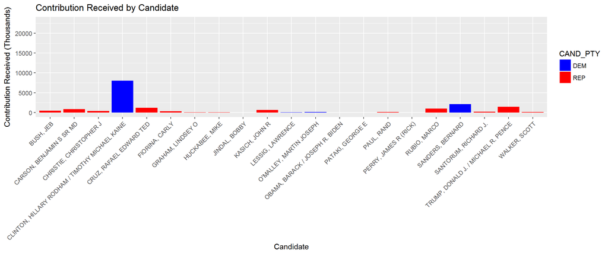

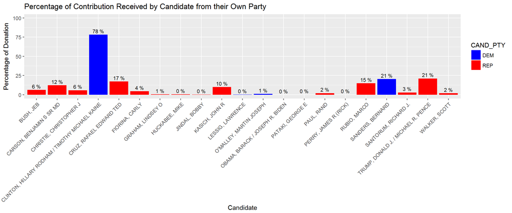

We have seen earlier that women made 14% more number of contributions than men. Is that the same for the amount of money donated? And do women tend to donate more to the liberals and/or to woman candidate?

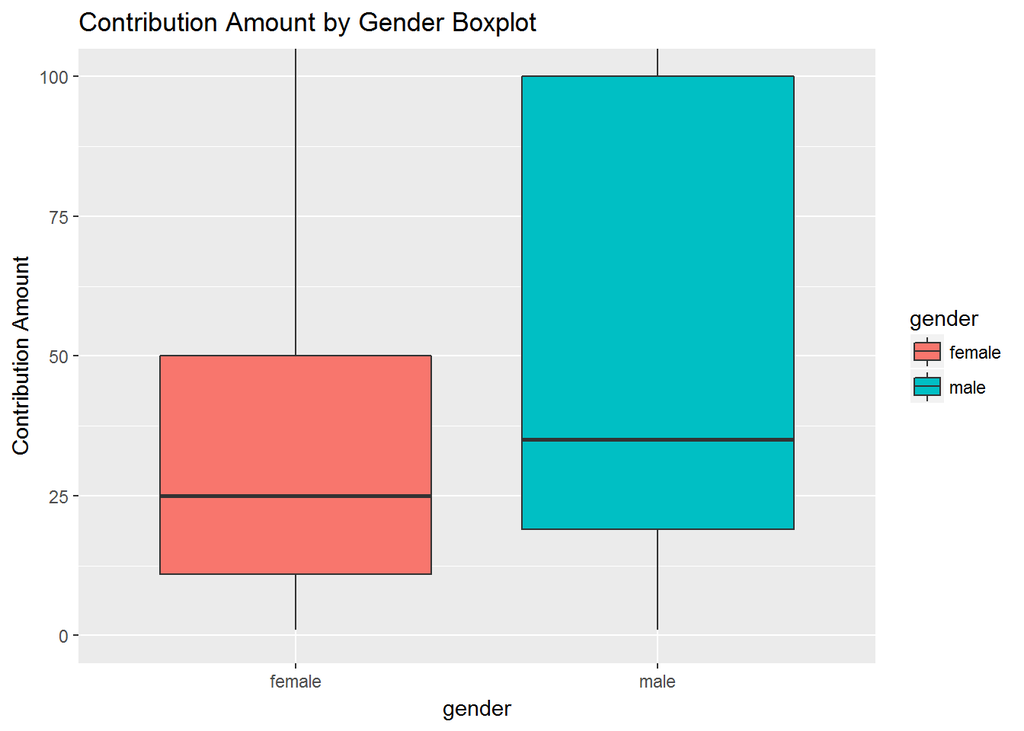

```
## fec_pa_Pres$gender: female
##    Min. 1st Qu.  Median    Mean 3rd Qu.    Max.
##    1.00   11.00   25.00   87.17   50.00 2700.00
## --------------------------------------------------------
## fec_pa_Pres$gender: male
##    Min. 1st Qu.  Median    Mean 3rd Qu.    Max.
##     1.0    19.0    35.0   133.4   100.0  2700.0
```

On average, male donated $133.4 and female donated $87.17, there is a 53% difference between genders. Female contributed much less than male when we look at median, mean and third quartile.

```
## # A tibble: 2 x 3
##   gender sum_gen     n
##   <chr>    <int> <int>
## 1 female 7280205 83657
## 2 male   9709416 72870
```

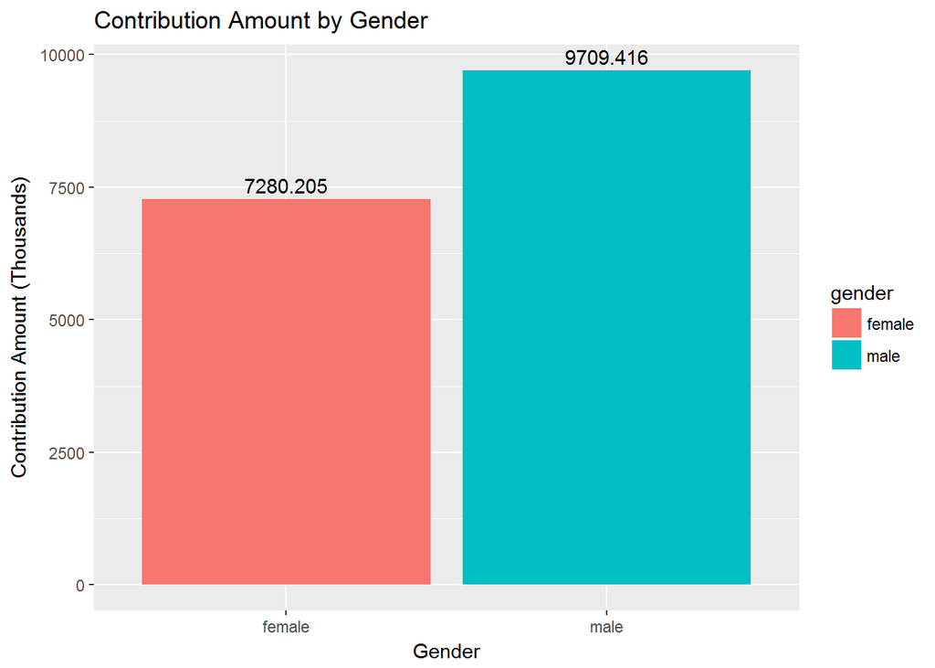

There is a significant difference of 33% between male and female contributions. Even though the no of contributions show that female contributions are more than male the amounts are definitely on the lower end when compared to male contribution amount.

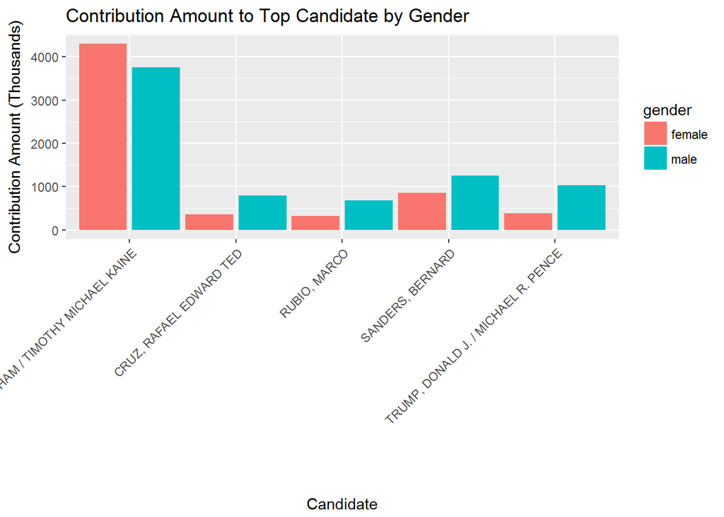

The above plot highlights that Hillary Clinton received highest contribution amount from women even though over all it shows women contributed less than men for the 2016 elections.

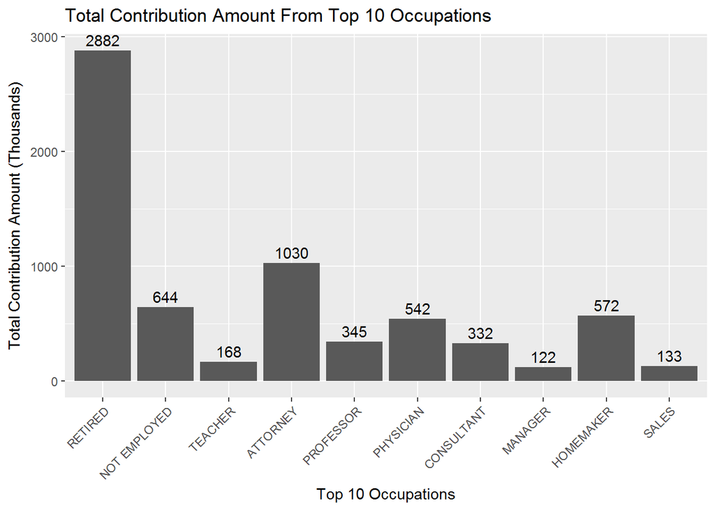

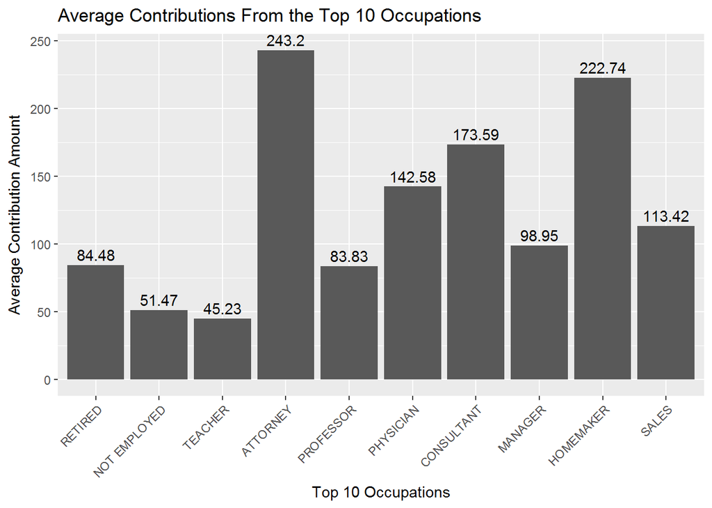

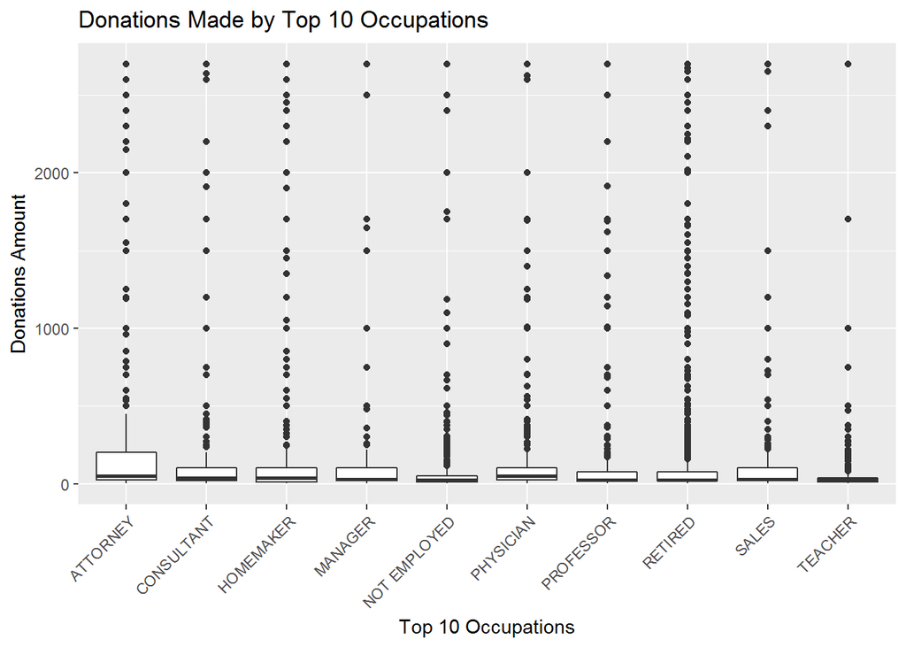

```
## top_occu_df$OCCUPATION: ATTORNEY
##    Min. 1st Qu.  Median    Mean 3rd Qu.    Max.
##     1.0    25.0    50.0   243.2   200.0  2700.0
## --------------------------------------------------------
## top_occu_df$OCCUPATION: CONSULTANT
##    Min. 1st Qu.  Median    Mean 3rd Qu.    Max.
##     1.0    19.0    35.5   173.6   100.0  2700.0
## --------------------------------------------------------
## top_occu_df$OCCUPATION: HOMEMAKER
##    Min. 1st Qu.  Median    Mean 3rd Qu.    Max.
##     1.0    11.0    35.0   222.7   100.0  2700.0
## --------------------------------------------------------
## top_occu_df$OCCUPATION: MANAGER
##    Min. 1st Qu.  Median    Mean 3rd Qu.    Max.
##    1.00   19.00   27.00   98.95  100.00 2700.00
## --------------------------------------------------------
## top_occu_df$OCCUPATION: NOT EMPLOYED
##    Min. 1st Qu.  Median    Mean 3rd Qu.    Max.
##    1.00   10.00   25.00   51.47   50.00 2700.00
## --------------------------------------------------------
## top_occu_df$OCCUPATION: PHYSICIAN
##    Min. 1st Qu.  Median    Mean 3rd Qu.    Max.
##     1.0    25.0    50.0   142.6   100.0  2700.0
## --------------------------------------------------------
## top_occu_df$OCCUPATION: PROFESSOR
##    Min. 1st Qu.  Median    Mean 3rd Qu.    Max.
##    1.00   15.00   25.00   83.83   75.00 2700.00
## --------------------------------------------------------
## top_occu_df$OCCUPATION: RETIRED
##    Min. 1st Qu.  Median    Mean 3rd Qu.    Max.
##    1.00   19.00   25.00   84.48   75.00 2700.00
## --------------------------------------------------------
## top_occu_df$OCCUPATION: SALES
##    Min. 1st Qu.  Median    Mean 3rd Qu.    Max.
##     1.0    20.0    27.0   113.4   100.0  2700.0
## --------------------------------------------------------
## top_occu_df$OCCUPATION: TEACHER
##    Min. 1st Qu.  Median    Mean 3rd Qu.    Max.
##    1.00   10.00   25.00   45.23   38.00 2700.00
```

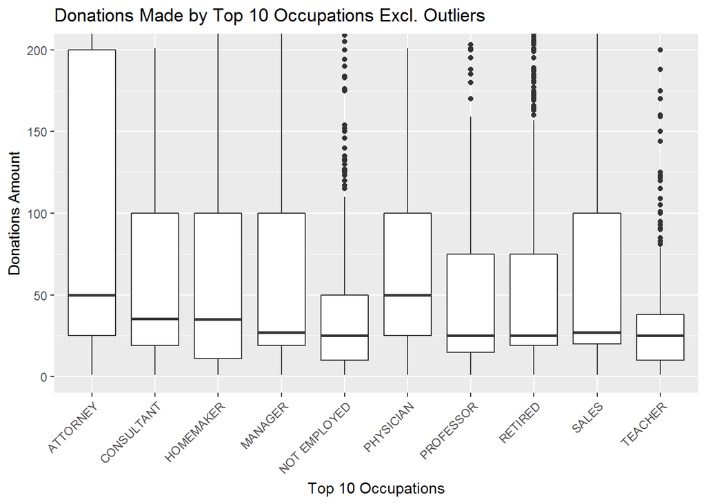

It is still apparent that attorney made the large contribution with the highest average donation and the largest variability. Some of them contributed 4 times of their respective median.

# Bivariate Analysis

### What was the strongest relationship you found?

Men had higher donation amount than women even though the number of contributions from Women are higher than men

# Multivariate Plots Section

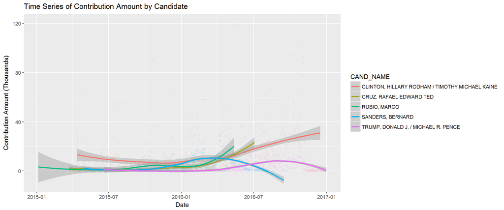

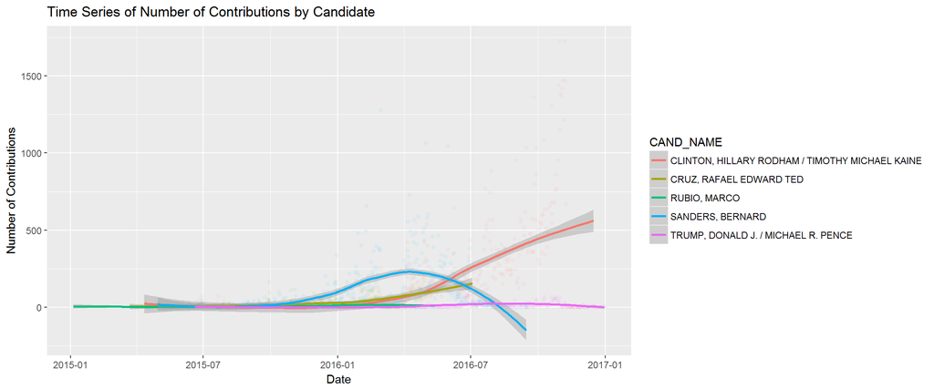

We know that Hillary Clinton raised the most money and had the most supporters in Pensylvania. But is this always true throughout the campaign process? When I look at above 2 graphs, I notice 2 things: 1.Bernard Sanders actually raised more money than Hillary Clinton starting from January 2016 and lasted for a few months almost through May 2016 2.Bernard Sanders actually had more supporters than Hillary Clinton from January 2016 onward until June 2016 when he announced to endorse Hillary Clinton that broke his supporters’ hearts.

This does pose an interesting question about what would have happened if Bernie sanders ran for president instead of Hillary.

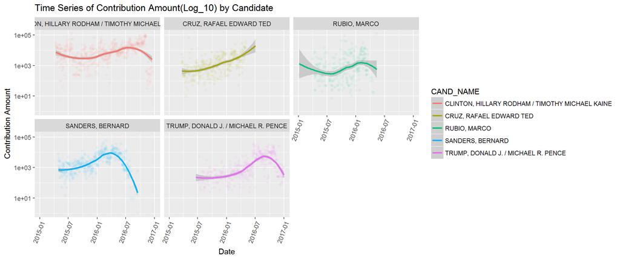

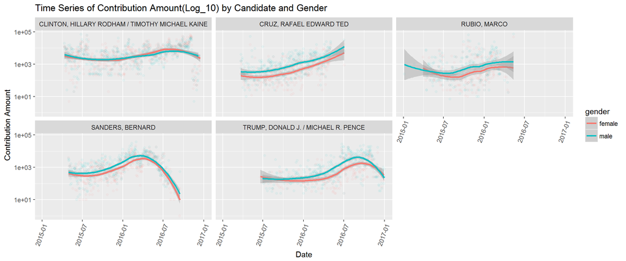

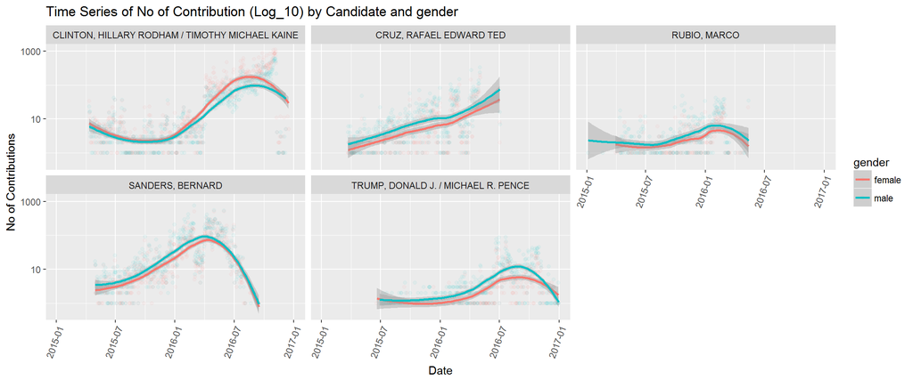

From the above Individual graphs of no of contributions and Contribution amounts gender wise are compared for all the top candidates. Only Hillary Clinton as a female candidate garnered more contributions from females. All the others have male contributions higher .

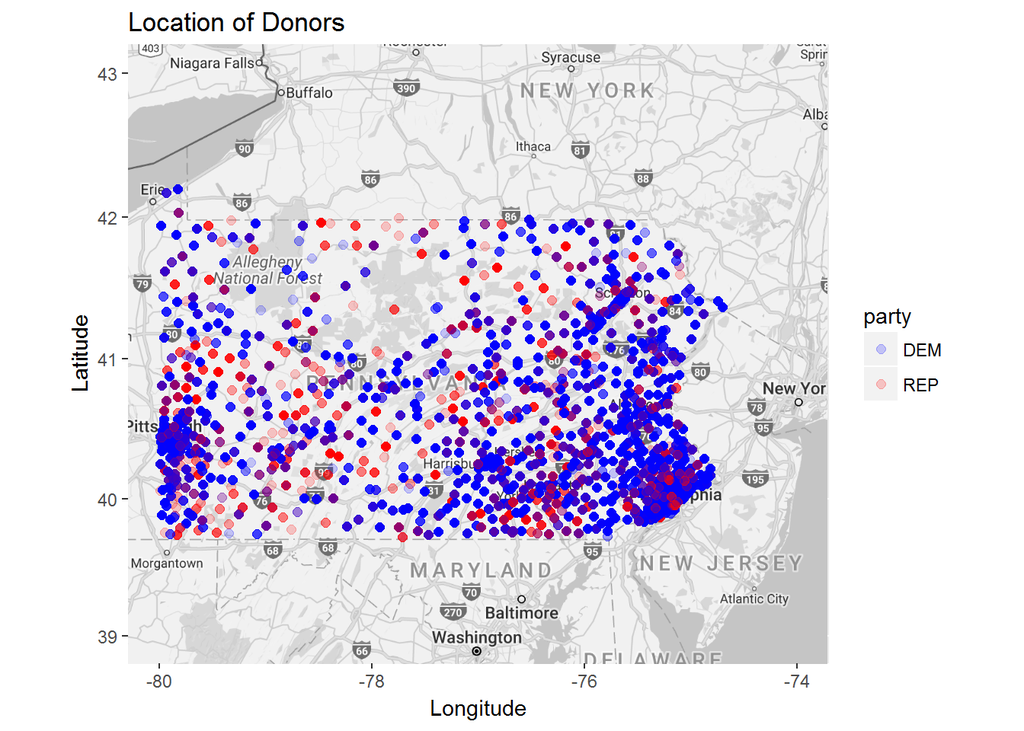

Now lets look at where the contributions came in the state. The map looks predominantly blue interspersed with red. The urban places like Philadelphia and Pittsburgh are more blue than the country side which fits with the general view that more liberals are the Urbanites.

# Predictive Modeling

In this section, I will make an attempt to apply logistic regression method to predict a donor’s contributing party giving his (or her) location (latitude, longitude), gender and donation amount. I will be taking the following steps: 1.Subset the original data set selecting the relevant columns only and make sure to filter out the ‘other’ party. 2.Clean and format data. 3.Remove negative sign in longitude for calculations. 4.Create a model to predict a donor’s contributing party based on gender, latitude, longitude and contribution receipt amount.

```
## [1] 156527
```

```
##
## Call:
## glm(formula = CAND_PTY ~ ., family = binomial(link = "logit"),
##     data = train)
##
## Deviance Residuals:
##     Min       1Q   Median       3Q      Max
## -2.1024  -0.7263  -0.5774  -0.5003   2.0762
##
## Coefficients:
##                   Estimate Std. Error z value Pr(>|z|)
## (Intercept)     -2.320e+01  5.836e-01  -39.75   <2e-16 ***
## TRANSACTION_AMT  7.951e-04  1.753e-05   45.36   <2e-16 ***
## gendermale       7.303e-01  1.410e-02   51.78   <2e-16 ***
## latitude         3.182e-01  1.538e-02   20.69   <2e-16 ***
## longitude        1.125e-01  3.780e-03   29.75   <2e-16 ***
## ---
## Signif. codes:  0 '***' 0.001 '**' 0.01 '*' 0.05 '.' 0.1 ' ' 1
##
## (Dispersion parameter for binomial family taken to be 1)
##
##     Null deviance: 134760  on 124983  degrees of freedom
## Residual deviance: 127650  on 124979  degrees of freedom
##   (16 observations deleted due to missingness)
## AIC: 127660
##
## Number of Fisher Scoring iterations: 4
```

First we see the deviance residuals, which are a measure of model fit. This part of output shows the distribution of the deviance residuals for individual cases used in the model. Below we discuss how to use summaries of the deviance statistic to assess model fit. For every one unit change in amount of contribution , contributing to Republican increase by 0.0008 The male voter is inclined to donate to a republican than a democrat compared to a female by 0.7 For a one unit increase in latitude, the log odds of contributing to Republican increases by 0.31 For a one unit increase in abs(longitude), the log odds of contributing to Republican increases by 0.11.

Next let us use the confint function to obtain confidence intervals for the coefficient estimates.

```
##                         2.5 %        97.5 %
## (Intercept)     -2.434141e+01 -2.205361e+01
## TRANSACTION_AMT  7.608307e-04  8.295407e-04
## gendermale       7.026570e-01  7.579444e-01
## latitude         2.880408e-01  3.483336e-01
## longitude        1.050630e-01  1.198810e-01
```

```
##                         2.5 %        97.5 %
## (Intercept)     -2.434194e+01 -2.205418e+01
## TRANSACTION_AMT  7.607161e-04  8.294192e-04
## gendermale       7.026374e-01  7.579244e-01
## latitude         2.880727e-01  3.483645e-01
## longitude        1.050656e-01  1.198835e-01
```

```
##     (Intercept) TRANSACTION_AMT      gendermale        latitude
##    8.418055e-11    1.000795e+00    2.075664e+00    1.374677e+00
##       longitude
##    1.119044e+00
```

```
##                           OR        2.5 %       97.5 %
## (Intercept)     8.418055e-11 2.683249e-11 2.643860e-10
## TRANSACTION_AMT 1.000795e+00 1.000761e+00 1.000830e+00
## gendermale      2.075664e+00 2.019110e+00 2.133885e+00
## latitude        1.374677e+00 1.333812e+00 1.416705e+00
## longitude       1.119044e+00 1.110781e+00 1.127363e+00
```

Now we can say that for a one unit increase in amount contributed, the odds of contributing to Republican increase by a factor of 1.0008

```
##
## model_pred_direction   DEM   REP
##                  DEM 30244  1153
##                  REP    51    79
```

```
## [1] 0.03818949
```

```
## [1] "Accuracy 0.961810511624956"
```

```
## [1] 7109.993
```

```
## [1] 4
```

```
## [1] 0
```

```
## 'log Lik.' -63824.98 (df=5)
```

The chi-square of 7109.993 with 4 degrees of freedom and an associated p-value of less than 0.001 tells us that our model as a whole fits significantly better than an empty model.

# Multivariate Analysis

### Were there any interesting or surprising interactions between features?

This poses an interesting speculation of how the election would have gone if Bernie was the candidate instead of Hillary? Moreover based on the number of contributions and the contribution amounts Pennsylvania comes up as a blue state but had gone for Republicans in the 2016 elections.

### OPTIONAL: Did you create any models with your dataset? Discuss the strengths and limitations of your model.?

I have created the logit model with the PA election data set for the predictive data analysis.

Logistic regression, also called a logit model, is used to model dichotomous outcome variables. In the logit model the log odds of the outcome is modeled as a linear combination of the predictor variables.

Based on the p- value and the test statistics the model is a good fit .

# Final Plots and Summary

### Percentage Contribution for each candidate by their own party

```
## # A tibble: 21 x 9
## # Groups:   CAND_PTY [2]
##    CAND_PTY CAND_NAME    sum_can mean_can   n.x sum_party number_of_candi~
##    <chr>    <chr>          <int>    <dbl> <int>     <int>            <int>
##  1 DEM      CLINTON, HI~ 8061472     96.8 83316  10286589                5
##  2 DEM      SANDERS, BE~ 2111493     49.0 43063  10286589                5
##  3 DEM      O'MALLEY, M~   98149    953     103  10286589                5
##  4 DEM      LESSIG, LAW~   15430    203      76  10286589                5
##  5 DEM      OBAMA, BARA~      45     45.0     1  10286589                5
##  6 REP      TRUMP, DONA~ 1417510    320    4425   6703032               16
##  7 REP      CRUZ, RAFAE~ 1149915    110   10472   6703032               16
##  8 REP      RUBIO, MARCO 1002831    397    2529   6703032               16
##  9 REP      CARSON, BEN~  822468     99.3  8281   6703032               16
## 10 REP      KASICH, JOH~  665744    661    1007   6703032               16
## # ... with 11 more rows, and 2 more variables: mean_party <dbl>, n.y <int>
```

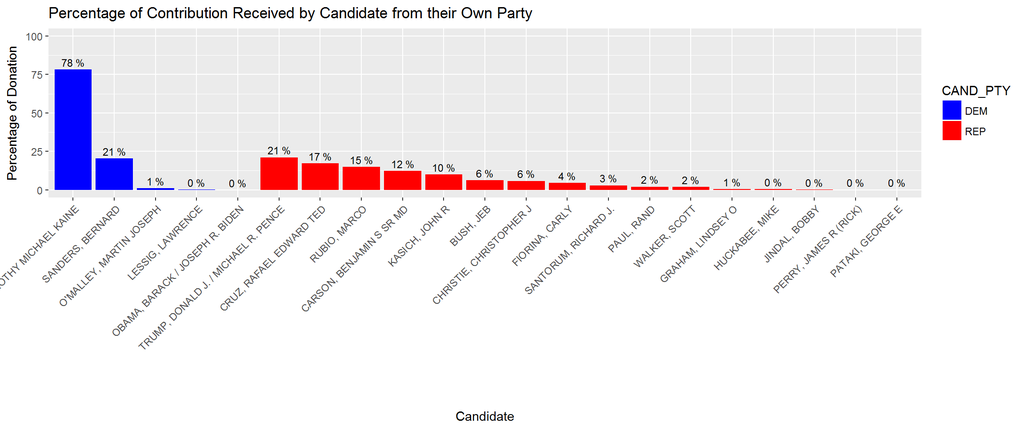

In Pensylvania, the financial donations to the presidential campaign went to the democrats by large. Especially in Democrats, 99% of the donations for Democrat went to two candidates Hillary Clinton and Bernie Sanders. The Republican donations are a little more evenly distributed atleast in the top 3 candidates.

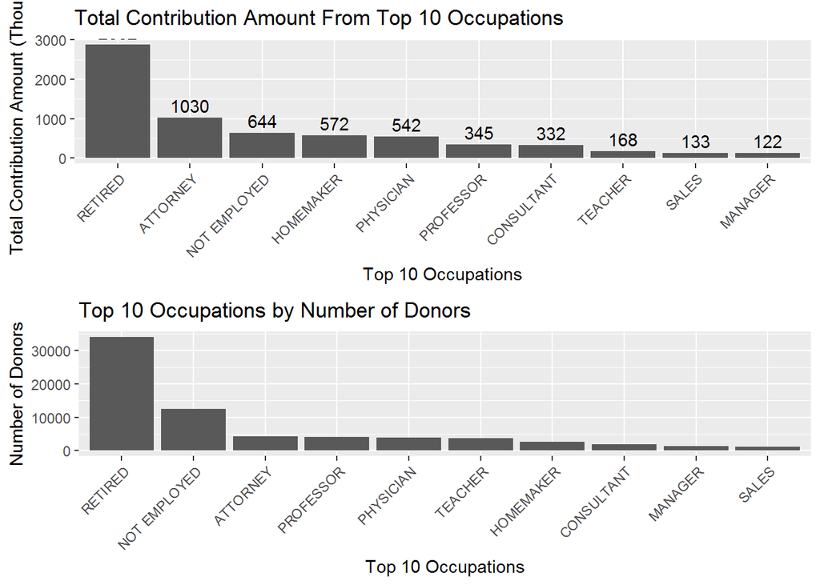

When we compare the presidential contributions by occupation in Pensylvania we see that the majority of the number of contributions have been made by people who do not have a traditional occupation. And even the amount of total contributions also is mostly donated by retired people. This is an intresting fact and indicates as if retired people take more intrest in politics.

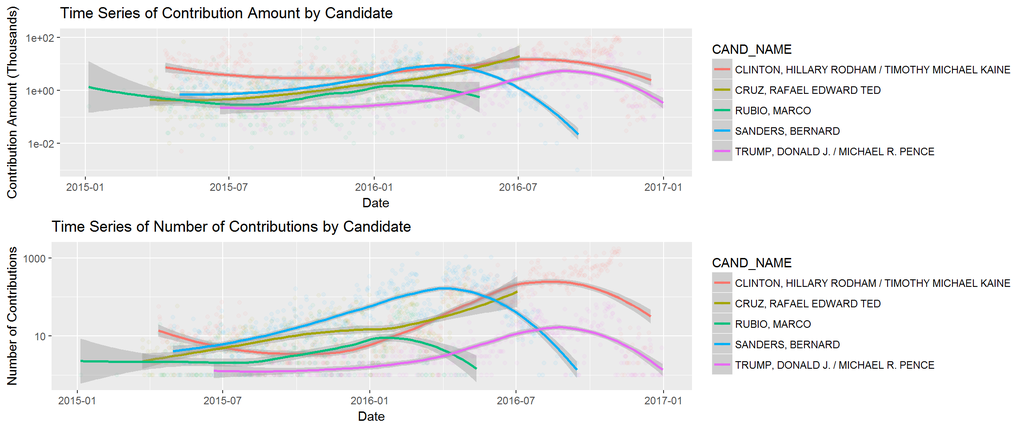

# Reflection

### Challenges and Struggles

The Pensylvania 2016 presidential campaign contributions data contains over 252093 entries from January 2015 until December 2016. Throughout the analysis, I had to deal with several issues: .The original data set did not contain gender information, to analyze the relationship between gender and donations, I added gender column using R’s gender package which used to predict gender from donor’s first name. .To see a better picture of donors’ geographic location, I added latitude and longitude columns using zip code package and I was able to create a map using ggmap after that. .The contribution date gave me a hard time when I had to convert the transaction_dt field from integer to char to a date. .I chose to omit negative contributions and contributions that exceed $2700 because of the Contribution Limits for 2015-2015 Federal Elections. However, I may have omitted big dollar donors. So use the data with caution. .I created a logistic aggression model in an attempt to predict donors’ contributing party based on other characteristics. However, I am not sure it is a good way to predict an individual’s contribution party. .I am not familiar with ggmap and logistics regression, and spent a lot of time on them.

### Success

.The ggplot2 and dplyr packages are the most important packages for this project. I also learned gender and zipcode packages and found they are powerful. .I learned a lot of new things throughout this project. Thanks to ggmap quick start, R-bloggers and Logistic Regression in R tutorial to make my project possible. It was a great experience.

### Conclusion

By analyzing Pensylvania’s financial contribution data, I found several interesting trends: .It is no doubt that Pensylvania is a swing state.The contributions by number and amounts suggest it is a blue state but the election results contradict that fact. .Few candidates collected the most donations. .Female donors tend to donate more to liberals and/or to female candidate. .The retired people are the largest contribution group by no of donations and the total amount. It is very intresting to note that the top two occupations by number of contributions is Retired and unemployed. .Bernard Sanders gained more popularity than Hillary Clinton until he gave up his run. Donald Trump also haven’t raised as much as Ted Cruz and Rubio until they dropped off. This hints that at least Pennsylvania voters didn’t get their favorite candidate as the primary winner in both parties

### Future Work

It would be interesting to see how the contributions are after the elections in Pennsylvania. I have only analyzed the contributions to presidential candidates for all parties. And also if we can analyze the contributions with age it would really provide some insights into how each age group leans to vote. It would also be great to compare the 2016 presidential elections with at least 2012 elections in respect to the contributions by party and gender.